# Zadanie domowe - EDA Danych dotyczących Irysów

- Twoim zadaniem jest wykonanie analizy danych zawartych w załączonym pliku CSV (`25__iris.csv`).
- Plik znajduje się pod video. Pamiętaj, żeby wrzucić plik do tego samego folderu, w którym znajduje się ten notebook.
- Wykorzystaj nowo nabytą wiedzę z biblioteki `Pandas`
- Jeżeli jest taka konieczność posiłkuj się [code explainerem](https://codeexplainer.imprv.ai/) lub / i [data chatterem](https://datachatter.imprv.ai/) (który również te dane ma dostępne).
- Prześlij na discordzie notebook z rozwiązaniem (`#modul-4-zad1`)
- Pamiętaj:
1. Nie spiesz się
2. Potraktuj zadanie domowe jak prawdziwy projekt
3. Dodawaj opisy, obserwacje, wnioski
4. Dodaj wizualizacje
5. Dodaj konkluzję i wnioski końcowe

Powodzenia!!! I mega zabawy!

## O Danych

Zbiór danych zawiera informacje o trzech gatunkach irysów: Iris setosa, Iris versicolor, i Iris virginica.

Dane obejmują pomiary czterech cech: długość i szerokość działki kielicha oraz długość i szerokość płatka.

Każdy wiersz w zbiorze danych reprezentuje pojedynczy kwiat, a wartości pomiarów są podane w centymetrach.

Zbiór składa się z 150 próbek, po 50 dla każdego gatunku, i jest szeroko stosowany jako podstawowy zbiór danych do testowania algorytmów klasyfikacji oraz w nauce o danych i uczeniu maszynowym.

Kolumny:

- **długość kielicha (sepal length)** - Długość kielicha w cm
- **szerokość kielicha (sepal width)** - Szerokość kielicha w cm
- **długość płatka (petal length)** - Długość płatka w cm
- **szerokość płatka (petal width)** - Szerokość płatka w cm
- **klasa (class)** - Klasa irysa (setosa, versicolor, virginica)

## Prezentacja danych

### Początkowe wiersze w dataframe

|  | długość kielicha (sepal length) | szerokość kielicha (sepal width) | długość płatka (petal length) | szerokość płatka (petal width) | klasa (class) |
| --- | --- | --- | --- | --- | --- |
| 0 | 5.100000 | 3.500000 | 1.400000 | 0.200000 | Iris-setosa |
| 1 | 4.900000 | 3.000000 | 1.400000 | 0.200000 | Iris-setosa |
| 2 | 4.700000 | 3.200000 | 1.300000 | 0.200000 | Iris-setosa |
| 3 | 4.600000 | 3.100000 | 1.500000 | 0.200000 | Iris-setosa |
| 4 | 5.000000 | 3.600000 | 1.400000 | 0.200000 | Iris-setosa |

### Losowe wiersze

|  | długość kielicha (sepal length) | szerokość kielicha (sepal width) | długość płatka (petal length) | szerokość płatka (petal width) | klasa (class) |
| --- | --- | --- | --- | --- | --- |
| 88 | 5.600000 | 3.000000 | 4.100000 | 1.300000 | Iris-versicolor |
| 115 | 6.400000 | 3.200000 | 5.300000 | 2.300000 | Iris-virginica |
| 58 | 6.600000 | 2.900000 | 4.600000 | 1.300000 | Iris-versicolor |
| 123 | 6.300000 | 2.700000 | 4.900000 | 1.800000 | Iris-virginica |
| 138 | 6.000000 | 3.000000 | 4.800000 | 1.800000 | Iris-virginica |
| 7 | 5.000000 | 3.400000 | 1.500000 | 0.200000 | Iris-setosa |
| 84 | 5.400000 | 3.000000 | 4.500000 | 1.500000 | Iris-versicolor |
| 3 | 4.600000 | 3.100000 | 1.500000 | 0.200000 | Iris-setosa |
| 24 | 4.800000 | 3.400000 | 1.900000 | 0.200000 | Iris-setosa |
| 37 | 4.900000 | 3.100000 | 1.500000 | 0.100000 | Iris-setosa |

### Ostatnie wartości

|  | długość kielicha (sepal length) | szerokość kielicha (sepal width) | długość płatka (petal length) | szerokość płatka (petal width) | klasa (class) |
| --- | --- | --- | --- | --- | --- |
| 145 | 6.700000 | 3.000000 | 5.200000 | 2.300000 | Iris-virginica |
| 146 | 6.300000 | 2.500000 | 5.000000 | 1.900000 | Iris-virginica |
| 147 | 6.500000 | 3.000000 | 5.200000 | 2.000000 | Iris-virginica |
| 148 | 6.200000 | 3.400000 | 5.400000 | 2.300000 | Iris-virginica |
| 149 | 5.900000 | 3.000000 | 5.100000 | 1.800000 | Iris-virginica |

## Informacje o kolumnach

```
<class 'pandas.core.frame.DataFrame'>
RangeIndex: 150 entries, 0 to 149
Data columns (total 5 columns):
 #   Column                            Non-Null Count  Dtype
---  ------                            --------------  -----
 0   długość kielicha (sepal length)   150 non-null    float64
 1   szerokość kielicha (sepal width)  150 non-null    float64
 2   długość płatka (petal length)     150 non-null    float64
 3   szerokość płatka (petal width)    150 non-null    float64
 4   klasa (class)                     150 non-null    object
dtypes: float64(4), object(1)
memory usage: 6.0+ KB
```

### Zbiorcze informacje o danych

Dane pogrupowane są w pięciu kolumnach, czterech liczbowych i jednej opisowej.

|  | długość kielicha (sepal length) | szerokość kielicha (sepal width) | długość płatka (petal length) | szerokość płatka (petal width) |
| --- | --- | --- | --- | --- |
| count | 150.000000 | 150.000000 | 150.000000 | 150.000000 |
| mean | 5.843333 | 3.054000 | 3.758667 | 1.198667 |
| std | 0.828066 | 0.433594 | 1.764420 | 0.763161 |
| min | 4.300000 | 2.000000 | 1.000000 | 0.100000 |
| 25% | 5.100000 | 2.800000 | 1.600000 | 0.300000 |
| 50% | 5.800000 | 3.000000 | 4.350000 | 1.300000 |
| 75% | 6.400000 | 3.300000 | 5.100000 | 1.800000 |
| max | 7.900000 | 4.400000 | 6.900000 | 2.500000 |

```
długość kielicha (sepal length)     35
szerokość kielicha (sepal width)    23
długość płatka (petal length)       43
szerokość płatka (petal width)      22
klasa (class)                        3
dtype: int64
```

## Analiza brakujących wartości

|  | długość kielicha (sepal length) | szerokość kielicha (sepal width) | długość płatka (petal length) | szerokość płatka (petal width) | klasa (class) |
| --- | --- | --- | --- | --- | --- |
| 0 | False | False | False | False | False |
| 1 | False | False | False | False | False |
| 2 | False | False | False | False | False |
| 3 | False | False | False | False | False |
| 4 | False | False | False | False | False |
| ... | ... | ... | ... | ... | ... |
| 145 | False | False | False | False | False |
| 146 | False | False | False | False | False |
| 147 | False | False | False | False | False |
| 148 | False | False | False | False | False |
| 149 | False | False | False | False | False |

150 rows × 5 columns

```
długość kielicha (sepal length)     0
szerokość kielicha (sepal width)    0
długość płatka (petal length)       0
szerokość płatka (petal width)      0
klasa (class)                       0
dtype: int64
```

### Podsumowanie brakujących wartości

Dane są kompletne, nie zawierają braków.

## Analiza pojedynczych zmiennych

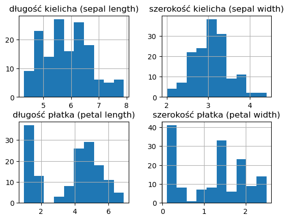

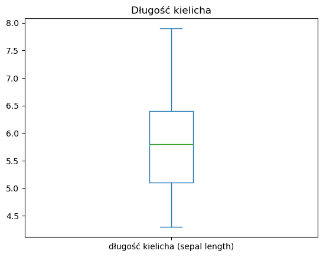

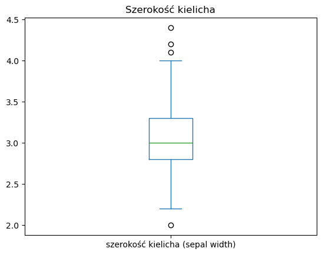

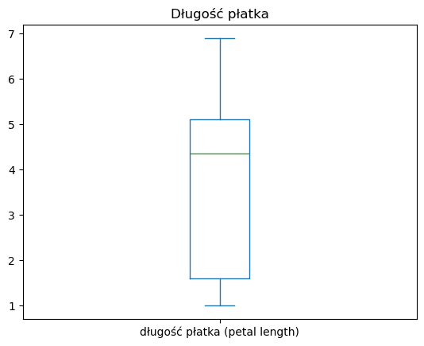

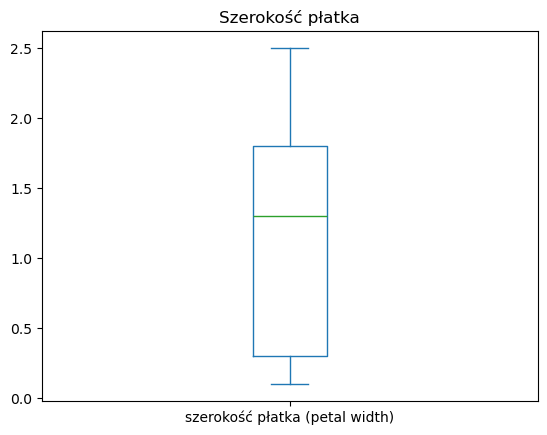

## Analiza zależności pomiędzy zmiennymi

### Długość kielicha, a klasa irysa

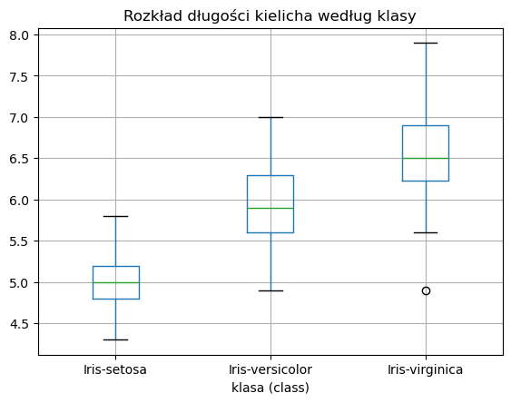

|  | klasa (class) | długość kielicha (sepal length) min | długość kielicha (sepal length) mean | długość kielicha (sepal length) median | długość kielicha (sepal length) max | długość kielicha (sepal length) std | długość kielicha (sepal length) count |
| --- | --- | --- | --- | --- | --- | --- | --- |
| 0 | Iris-setosa | 4.300000 | 5.006000 | 5.000000 | 5.800000 | 0.352490 | 50 |
| 1 | Iris-versicolor | 4.900000 | 5.936000 | 5.900000 | 7.000000 | 0.516171 | 50 |
| 2 | Iris-virginica | 4.900000 | 6.588000 | 6.500000 | 7.900000 | 0.635880 | 50 |